# pirouette demo

Richèl J.C. Bilderbeek

2023-10-07

The goal of `pirouette` is to estimate the error BEAST2 makes from a known phylogeny. This phylogeny can be created using a non-BEAST speciation model, for example the PBD or MBD models.

```r
library(pirouette)
```

`pirouette` has a the option to do model comparison, picking the model that has most evidence (aka marginal likelihood). This option only works under Linux and Mac. When working on such a system, the BEAST2 package ‘NS’ is expected to be installed.

In this demo, we use a simple ‘true’ phylogeny:

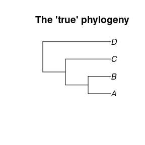

```r
true_phylogeny <- ape::read.tree(text = "(((A:1, B:1):1, C:2):1, D:3);")
ape::plot.phylo(true_phylogeny, main = "The 'true' phylogeny")
```

As this vignette is a demo (and not a thorough research), we’ll use a short alignment:

```r
alignment_params <- create_alignment_params(
  root_sequence = create_blocked_dna(length = 20)
)
```

## 1. Only use the generative model in inference

There are multiple ways to select for an inference model. In the simplest case, which is the default, we will do our inference with the generative model only:

| type | run_if | measure evidence | inference model |
| --- | --- | --- | --- |
| generative | always | FALSE | Default |

```r
experiment <- create_test_gen_experiment()
experiments <- list(experiment)
```

Here we measure the baseline error: the error that BEAST2 makes when the inference model is the correct generative model (JC69 and strict clock):

```r
pir_params <- create_pir_params(
  alignment_params = alignment_params,
  experiments = experiments
)
```

Running it:

```r
errors <- NULL

if (beastier::is_beast2_installed()) {
  errors <- pir_run(
    phylogeny = true_phylogeny,
    pir_params = pir_params
  )
} else {
  errors <- create_test_pir_run_output(
    add_twin = FALSE,
    add_best = FALSE
  )
}
```

Here we show the errors as a table:

```r
knitr::kable(utils::head(errors))
```

| tree | inference_model | inference_model_weight | site_model | clock_model | tree_prior | error_1 | error_2 | error_3 | error_4 |
| --- | --- | --- | --- | --- | --- | --- | --- | --- | --- |
| true | generative | NA | JC69 | strict | yule | 0.0288594 | 0.0511771 | 0.1149183 | 0.0908139 |

Here we plot the error:

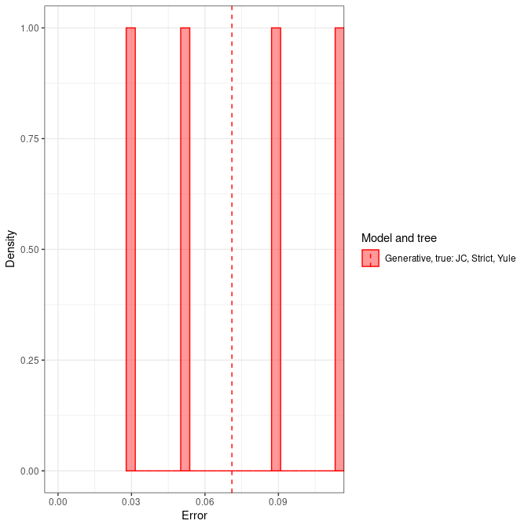

```r
pir_plot(errors)
```

## 2. Do inference on candidate models

Again, there are multiple ways to select for which inference model(s) to use. Here we assume we do not know the generative model. Instead, we only run the inference model that has the highest evidence (also called ‘marginal likelihood’).

| type | run_if | measure evidence | inference model |
| --- | --- | --- | --- |
| candidate | best_candidate | TRUE | Yule |
| candidate | best_candidate | TRUE | Birth-Death |

```r
if (rappdirs::app_dir()$os != "win") {
  experiment_yule <- create_test_cand_experiment(
    inference_model = beautier::create_test_inference_model(
      tree_prior = beautier::create_yule_tree_prior()
    )
  )
  experiment_bd <- create_test_cand_experiment(
    inference_model = beautier::create_test_inference_model(
      tree_prior = beautier::create_bd_tree_prior()
    )
  )
  # Use the same files to work on, as only one will actually run an experiment
  experiment_bd$beast2_options <- experiment_yule$beast2_options
  experiment_bd$inference_model$mcmc <- experiment_yule$inference_model$mcmc
  experiment_bd$errors_filename <- experiment_yule$errors_filename

  experiments <- list(experiment_yule, experiment_bd)
  check_experiments(experiments)

  pir_params <- create_pir_params(
    alignment_params = alignment_params,
    experiments = experiments,
    evidence_filename = get_temp_evidence_filename()
  )
}
```

Run this setup:

```r
if (rappdirs::app_dir()$os != "win" &&
    beastier::is_beast2_installed() &&
    mauricer::is_beast2_ns_pkg_installed()
) {
  errors <- pir_run(
    phylogeny = true_phylogeny,
    pir_params = pir_params
  )
} else {
  errors <- create_test_pir_run_output(add_best = TRUE)
}
```

Here we show the errors as a table:

```r
knitr::kable(utils::head(errors))
```

| tree | inference_model | inference_model_weight | site_model | clock_model | tree_prior | error_1 | error_2 | error_3 |
| --- | --- | --- | --- | --- | --- | --- | --- | --- |
| true | generative | 0.5 | JC69 | relaxed_log_normal | birth_death | 0.1 | 0.11 | 0.12 |
| true | candidate | 0.4 | HKY | strict | coalescent_bayesian_skyline | 0.2 | 0.23 | 0.24 |

Here we plot the error:

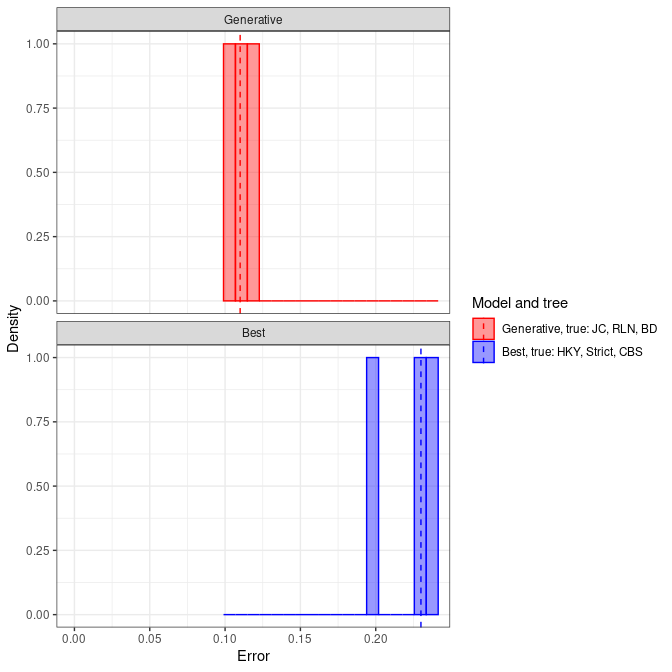

```r
pir_plot(errors)
```

## 3. Do inference with the generative and model with most evidence

Again, there are multiple ways to select for which inference model(s) to use. Next to the known generative model (JC69 and strict clock), here we use the inference model that has the highest evidence (also called ‘marginal likelihood’).

Here we measure the baseline error, from the generative model, and the error that BEAST2 makes when the inference model is the one with most evidence:

| type | run_if | measure evidence | inference model |
| --- | --- | --- | --- |
| generative | always | FALSE | Yule |
| candidate | best_candidate | TRUE | Birth-Death |

```r
experiment_yule <- create_test_gen_experiment(
  inference_model = beautier::create_test_inference_model(
    tree_prior = beautier::create_yule_tree_prior()
  )
)
if (rappdirs::app_dir()$os != "win") {
  experiment_bd <- create_test_cand_experiment(
    inference_model = beautier::create_test_inference_model(
      tree_prior = beautier::create_bd_tree_prior()
    )
  )
  experiments <- list(experiment_yule, experiment_bd)

  pir_params <- create_pir_params(
    alignment_params = create_test_alignment_params(),
    experiments = experiments,
    evidence_filename = get_temp_evidence_filename()
  )

} else {
  experiments <- list(experiment_yule)

  pir_params <- create_pir_params(
    alignment_params = create_test_alignment_params(),
    experiments = experiments
  )
}
```

Run this setup:

```r
if (rappdirs::app_dir()$os != "win" &&
    beastier::is_beast2_installed() &&
    mauricer::is_beast2_ns_pkg_installed()
) {
  errors <- pir_run(
    phylogeny = true_phylogeny,
    pir_params = pir_params
  )
} else {
  errors <- create_test_pir_run_output(add_best = TRUE)
}
```

Here we show the errors as a table:

```r
knitr::kable(utils::head(errors))
```

| tree | inference_model | inference_model_weight | site_model | clock_model | tree_prior | error_1 | error_2 | error_3 |
| --- | --- | --- | --- | --- | --- | --- | --- | --- |
| true | generative | 0.5 | JC69 | relaxed_log_normal | birth_death | 0.1 | 0.11 | 0.12 |
| true | candidate | 0.4 | HKY | strict | coalescent_bayesian_skyline | 0.2 | 0.23 | 0.24 |

Here we plot the error:

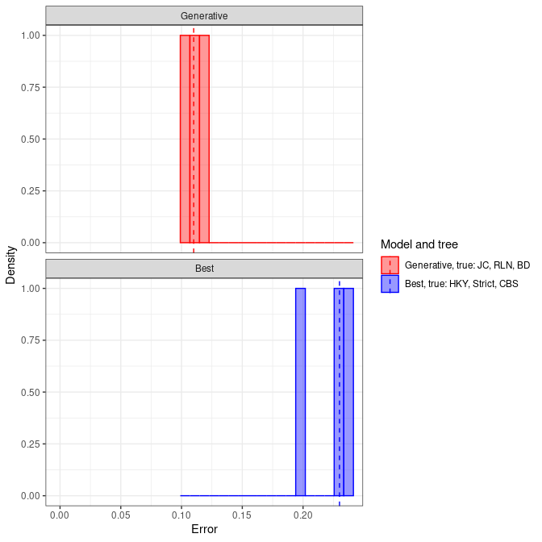

```r
pir_plot(errors)
```